# Test a Perceptual Phenomenon

### Analyzing the Stroop Effect

Perform the analysis in the space below. Remember to follow [the instructions](https://docs.google.com/document/d/1-OkpZLjG_kX9J6LIQ5IltsqMzVWjh36QpnP2RYpVdPU/pub?embedded=True) and review the [project rubric](https://review.udacity.com/#!/rubrics/71/view) before submitting. Once you've completed the analysis and write-up, download this file as a PDF or HTML file, upload that PDF/HTML into the workspace here (click on the orange Jupyter icon in the upper left then Upload), then use the Submit Project button at the bottom of this page. This will create a zip file containing both this .ipynb doc and the PDF/HTML doc that will be submitted for your project.

(1) What is the independent variable? What is the dependent variable?

independent variable:Congruent or Incongruent condition dependent variable: How much time to complete the test (Response time)

(2) What is an appropriate set of hypotheses for this task? Specify your null and alternative hypotheses, and clearly define any notation used. Justify your choices.

Null Hypothesis: the Congruent condition has no significant difference as much as the Incongruent condition ( no time difference between Incongruent and Congruent) Alternative Hypothesis: the Incongruent condition has a significant difference compared to Congruent condition (Incongruent take more time than Congruent)

μd is mean difference H0:μd=0 H1:μd!=0

The appropriate statistical test for this task is t-test because there are two different conditions that has been assigned to the same subject and those conditions is dependent and by so a mean between them must be compared to conclude the statistically significant difference also because the population standard deviations is unknown

(3) Report some descriptive statistics regarding this dataset. Include at least one measure of central tendency and at least one measure of variability. The name of the data file is 'stroopdata.csv'.

```python
import math
import pandas as pd
import numpy as np
import seaborn as sns
from scipy.stats import t
import matplotlib.pyplot as plt
%matplotlib inline

# read csv file and assign to df
df = pd.read_csv('stroopdata.csv')
# display the first 5 rows
df.head()
```

|  | Congruent | Incongruent |
| --- | --- | --- |
| 0 | 12.079 | 19.278 |
| 1 | 16.791 | 18.741 |
| 2 | 9.564 | 21.214 |
| 3 | 8.630 | 15.687 |
| 4 | 14.669 | 22.803 |

```python
#show the mean for both Congruent and Inongruent
print (df.Congruent.mean() , df.Incongruent.mean())
```

```
14.051125 22.0159166667
```

```python
#show the standard deviation for both Congruent and Inongruent
print (df.Congruent.std() , df.Incongruent.std())
```

```
3.55935795765 4.79705712247
```

(4) Provide one or two visualizations that show the distribution of the sample data. Write one or two sentences noting what you observe about the plot or plots.

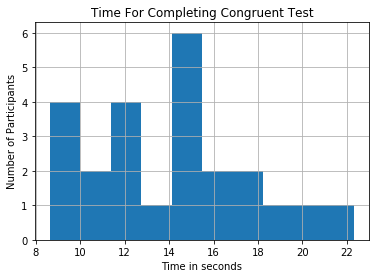

```python
#Congruent histogram
df.Congruent.hist()
# x label name
plt.xlabel('Time in seconds')
# y label name
plt.ylabel('Number of Participants')
# title name
plt.title('Time For Completing Congruent Test');
```

The heighest number of participants is 6 and 6 has taken between 14 and 16 for Completing Congruent Test

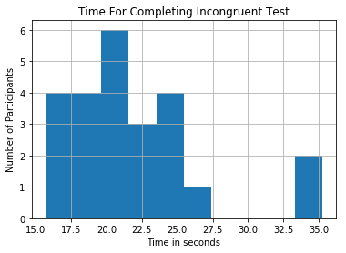

```python
#Incongruent histogram
df.Incongruent.hist()
# x label name
plt.xlabel('Time in seconds')
# y label name
plt.ylabel('Number of Participants')
# title name
plt.title('Time For Completing Incongruent Test');
```

(5) Now, perform the statistical test and report your results. What is your confidence level or Type I error associated with your test? What is your conclusion regarding the hypotheses you set up? Did the results match up with your expectations? **Hint:** Think about what is being measured on each individual, and what statistic best captures how an individual reacts in each environment.

```python
# size of sample
print(df.Congruent.size)
print(df.Incongruent.size)
```

```
24
24
```

tc=24-1=23 Confidence level is 90% and the probability is 0.05 t-critical is 1.714 (https://www.stat.tamu.edu/~lzhou/stat302/T-Table.pdf)

```python
#sample statistic
stat=(df.Incongruent- df.Congruent).std()
stat
```

```
4.8648269103590556
```

```python
# point
pMean=df.Incongruent.mean() - df.Congruent.mean()
pMean
```

```
7.9647916666666667
```

```python
#t-statistic
tStat = pMean /(stat/ math.sqrt(24))
tStat
```

```
8.020706944109957
```

```python
from subprocess import call
call(['python', '-m', 'nbconvert', 'Test a Perceptual Phenomenon.ipynb'])
```

```
0
```